# Figure1_20220224

# Figure1

required libraries

```
## Setting options('download.file.method.GEOquery'='auto')
```

```
## Setting options('GEOquery.inmemory.gpl'=FALSE)
```

Load data and build SEs

```r
STR2d <- readRDS("../data/STR2.dHC.SE.rds")
STR2v <- readRDS("../data/STR2.vHC.SE.rds")
STR3 <- readRDS("../data/STR3.vHC.SE.rds")

STR2 <- cbind(STR2d,STR2v)
STR2$SampleNumber <- NULL
STR <- cbind(STR2,STR3)
STR$Condition2[STR$Condition2 == "Saline-Ctrl"] <- "PBS-Control"
STR$Condition2[STR$Condition2 == "Saline-Stress"] <- "PBS-Stress"
STR$Condition2 <- droplevels(STR$Condition2)
STR$Condition[STR$Condition == "Control"] <- "Homecage"
STR <- dosvacor(STR, form = ~Condition2 + Experiment + Region, form0 = ~Experiment + Region)
```

```
##   Note: levels of factors in the design contain characters other than
##   letters, numbers, '_' and '.'. It is recommended (but not required) to use
##   only letters, numbers, and delimiters '_' or '.', as these are safe characters
##   for column names in R. [This is a message, not a warning or an error]
```

```
##   Note: levels of factors in the design contain characters other than
##   letters, numbers, '_' and '.'. It is recommended (but not required) to use
##   only letters, numbers, and delimiters '_' or '.', as these are safe characters
##   for column names in R. [This is a message, not a warning or an error]
```

```
## Number of significant surrogate variables is:  10
## Iteration (out of 5 ):1  2  3  4  5
```

```r
STR2 <- dosvacor(STR2, form = ~Condition + Injection, form0 = ~Region)
```

```
## Number of significant surrogate variables is:  5
## Iteration (out of 5 ):1  2  3  4  5
```

```r
STR2 <- STR2[,order(STR2$Region,STR2$Condition2)]
STR3 <- STR3[,order(STR3$Injection,STR3$Condition,STR3$Sex)]


Results <- list()

mincount <- 30
```

## Figure 1: STR2 Analysis of dHC and vHC

```r
#dHC
STR2d$Condition2 <- droplevels(STR2d$Condition2)
STR2d <- dosvacor(STR2d,form = ~Condition2)
```

```
##   Note: levels of factors in the design contain characters other than
##   letters, numbers, '_' and '.'. It is recommended (but not required) to use
##   only letters, numbers, and delimiters '_' or '.', as these are safe characters
##   for column names in R. [This is a message, not a warning or an error]
##   Note: levels of factors in the design contain characters other than
##   letters, numbers, '_' and '.'. It is recommended (but not required) to use
##   only letters, numbers, and delimiters '_' or '.', as these are safe characters
##   for column names in R. [This is a message, not a warning or an error]
```

```
## Number of significant surrogate variables is:  5
## Iteration (out of 5 ):1  2  3  4  5
```

```r
STR2d <- STR2d[,order(STR2d$Injection,STR2d$Condition)]

STR2d_design <- model.matrix(~STR2d$Condition2 + STR2d$SV1 + STR2d$SV2 + STR2d$SV3 + STR2d$SV4 + STR2d$SV5)

y <- DGEList(counts=assays(STR2d)$counts)
y <- calcNormFactors(y)
y <- estimateDisp(y,STR2d_design)
#filter out genes that are low expressed
y <- y[filterByExpr(y, STR2d_design, min.count = mincount),]
STR2d_fit <- glmQLFit(y,STR2d_design)

#vHC
STR2v$Condition2 <- droplevels(STR2v$Condition2)
STR2v <- dosvacor(STR2v,form = ~Condition2)
```

```
##   Note: levels of factors in the design contain characters other than
##   letters, numbers, '_' and '.'. It is recommended (but not required) to use
##   only letters, numbers, and delimiters '_' or '.', as these are safe characters
##   for column names in R. [This is a message, not a warning or an error]
##   Note: levels of factors in the design contain characters other than
##   letters, numbers, '_' and '.'. It is recommended (but not required) to use
##   only letters, numbers, and delimiters '_' or '.', as these are safe characters
##   for column names in R. [This is a message, not a warning or an error]
```

```
## Number of significant surrogate variables is:  3
## Iteration (out of 5 ):1  2  3  4  5
```

```r
STR2v <- STR2v[,order(STR2v$Injection,STR2v$Condition)]

STR2v_design <- model.matrix(~STR2v$Condition2 + STR2v$SV1 + STR2v$SV2 + STR2v$SV3)

y <- DGEList(counts=assays(STR2v)$counts)
y <- calcNormFactors(y)
y <- estimateDisp(y,STR2v_design)
#filter out genes that are low expressed
y <- y[filterByExpr(y, STR2v_design, min.count = mincount),]
STR2v_fit <- glmQLFit(y,STR2v_design)
```

### Stress responsive genes (HeatMap Fig1B)

The this Figure will show all genes that are stress responsive in dHC or vHC as one single Heatmap

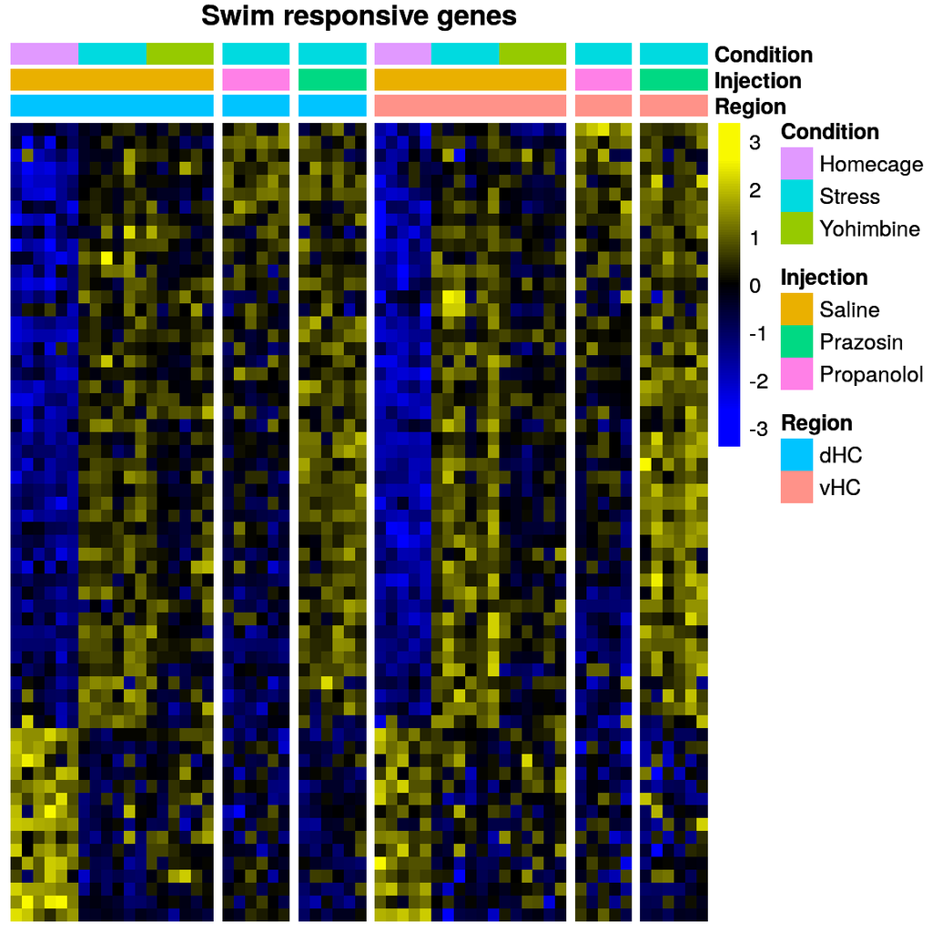

```r
Results[["STR2d_FullModel"]] <- glmQLFTest(STR2d_fit, colnames(STR2d_design)[2:5])
Results[["STR2v_FullModel"]] <- glmQLFTest(STR2v_fit, colnames(STR2v_design)[2:5])
Results[["STR2d_StressEffect"]] <- glmQLFTest(STR2d_fit, contrast = c(0,1,1,0,0,0,0,0,0,0))
Results[["STR2v_StressEffect"]] <- glmQLFTest(STR2v_fit, contrast = c(0,1,1,0,0,0,0,0))
Results[["STR2v_CtrlvsSwim"]] <- glmQLFTest(STR2v_fit, contrast = c(0,1,0,0,0,0,0,0))
Results[["STR2d_CtrlvsSwim"]] <- glmQLFTest(STR2d_fit, contrast = c(0,1,0,0,0,0,0,0,0,0))



#Genes that are significant in either dHC or vHC
sig_str <- union(rownames(topTags(Results[["STR2d_StressEffect"]], p = 0.05, n = Inf)),rownames(topTags(Results[["STR2v_StressEffect"]], p = 0.05, n = Inf)))
sig_sw <- union(rownames(topTags(Results[["STR2v_CtrlvsSwim"]], p = 0.05, n = Inf)),rownames(topTags(Results[["STR2d_CtrlvsSwim"]], p = 0.05, n = Inf)))
sig <- union(rownames(topTags(Results[["STR2d_FullModel"]], p = 0.05, n = Inf)),rownames(topTags(Results[["STR2v_FullModel"]], p = 0.05, n = Inf)))

Fig1B <- sehm(STR2,
     sig_sw,
     gaps_at = c("Region","Injection"),
     anno_columns = c("Region","Injection","Condition"),
     sortRowsOn = which(STR2$Injection == "Propanolol" | STR2$Condition == "Homecage"),
     do.scale = T,
     main = "Swim responsive genes", assay = "corrected",)

print(Fig1B)
```

### Contrast analysis (Yohimbine effects, Propranolol effects and Prazosin effects) (Volcanos Fig1C and FigS1A)

This Figure will show Volcanoplots for contrast analyses in dHC and vHC independently Contrasts are shown for

Main Figure - Ctrl vs Swim - Ctrl vs Yohimbine - Ctrl vs Prop - Ctrl vs Praz

```r
Results[["STR2v_SwimvsYohimb"]] <- glmQLFTest(STR2v_fit, contrast = c(0,-1,1,0,0,0,0,0))
Results[["STR2v_StressvsPraz"]] <- glmQLFTest(STR2v_fit, contrast = c(0,-1,-1,0,1,0,0,0))
Results[["STR2v_StressvsPropr"]] <- glmQLFTest(STR2v_fit, contrast = c(0,-1,-1,1,0,0,0,0))
Results[["STR2v_CtrlvsPropr"]] <- glmQLFTest(STR2v_fit, contrast = c(0,0,0,1,0,0,0,0))
Results[["STR2v_CtrlvsYohimb"]] <- glmQLFTest(STR2v_fit, contrast = c(0,0,1,0,0,0,0,0))
Results[["STR2v_CtrlvsPraz"]] <- glmQLFTest(STR2v_fit, contrast = c(0,0,0,0,1,0,0,0))

Results[["STR2d_SwimvsYohimb"]] <- glmQLFTest(STR2d_fit, contrast = c(0,-1,1,0,0,0,0,0,0,0))
Results[["STR2d_StressvsPraz"]] <- glmQLFTest(STR2d_fit, contrast = c(0,-1,-1,0,1,0,0,0,0,0))
Results[["STR2d_StressvsPropr"]] <- glmQLFTest(STR2d_fit, contrast = c(0,-1,-1,1,0,0,0,0,0,0))
Results[["STR2d_CtrlvsPropr"]] <- glmQLFTest(STR2d_fit, contrast = c(0,0,0,1,0,0,0,0,0,0))
Results[["STR2d_CtrlvsYohimb"]] <- glmQLFTest(STR2d_fit, contrast = c(0,0,1,0,0,0,0,0,0,0))
Results[["STR2d_CtrlvsPraz"]] <- glmQLFTest(STR2d_fit, contrast = c(0,0,0,0,1,0,0,0,0,0))
```

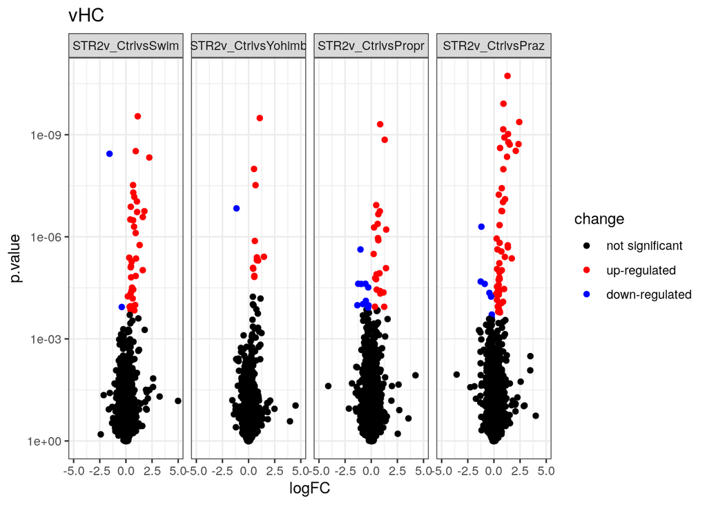

```r
VolcanovHC <- VolcanoPlotsEdgeR(Results[c("STR2v_CtrlvsSwim","STR2v_CtrlvsYohimb","STR2v_CtrlvsPropr","STR2v_CtrlvsPraz")],main = "vHC",limits = c(-5,5))
```

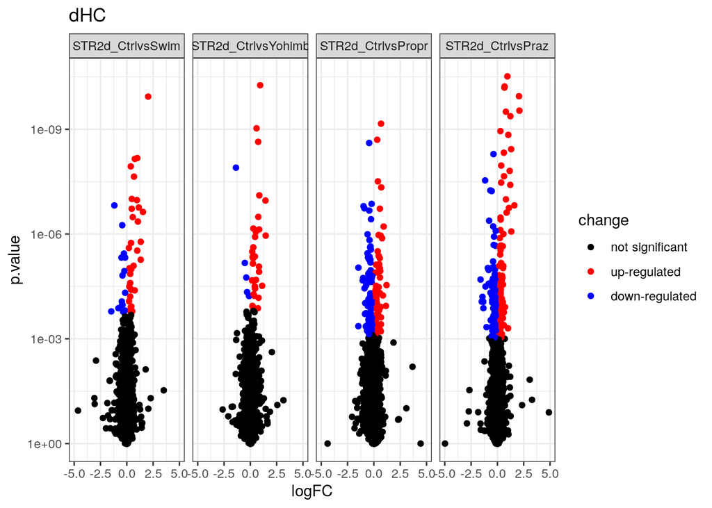

```r
VolcanodHC <- VolcanoPlotsEdgeR(Results[c("STR2d_CtrlvsSwim","STR2d_CtrlvsYohimb","STR2d_CtrlvsPropr","STR2d_CtrlvsPraz")], main = "dHC",limits = c(-5,5))
```

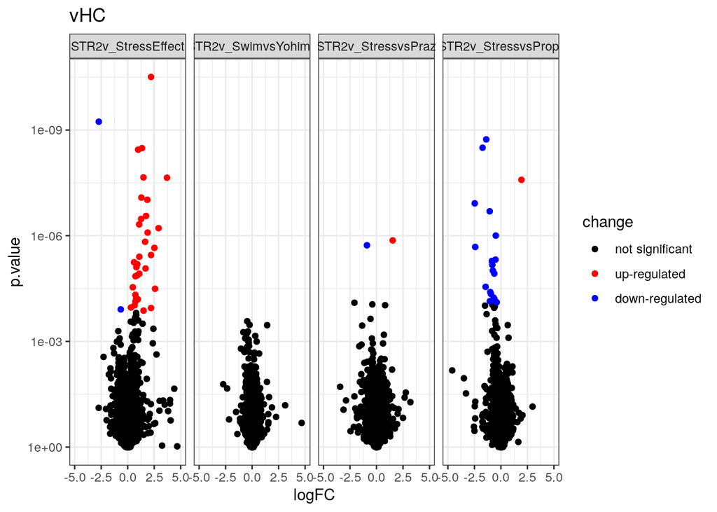

```r
Fig1C <- plot_grid(VolcanovHC,VolcanodHC,ncol = 1)
VolcanovHC_S <- VolcanoPlotsEdgeR(Results[c("STR2v_StressEffect","STR2v_SwimvsYohimb","STR2v_StressvsPraz","STR2v_StressvsPropr")],main = "vHC",limits = c(-5,5))
```

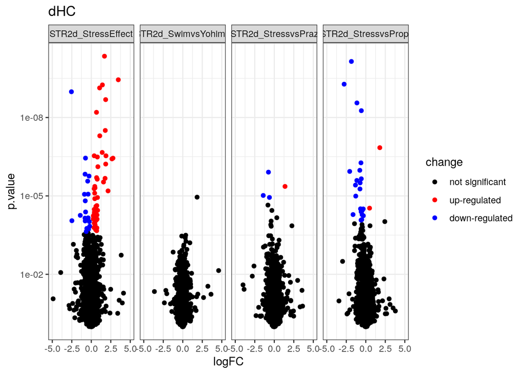

```r
VolcanodHC_S <- VolcanoPlotsEdgeR(Results[c("STR2d_StressEffect","STR2d_SwimvsYohimb","STR2d_StressvsPraz","STR2d_StressvsPropr")], main = "dHC",limits = c(-5,5))
```

```r
FigS1A <- plot_grid(VolcanovHC_S,VolcanodHC_S,ncol = 1)
```

### Propranolol Responsive Genes (Heatmap Fig1D)

This figure shows a heatmap of all genes that have a significant stress vs stress + propranolo difference in vHC or dHC

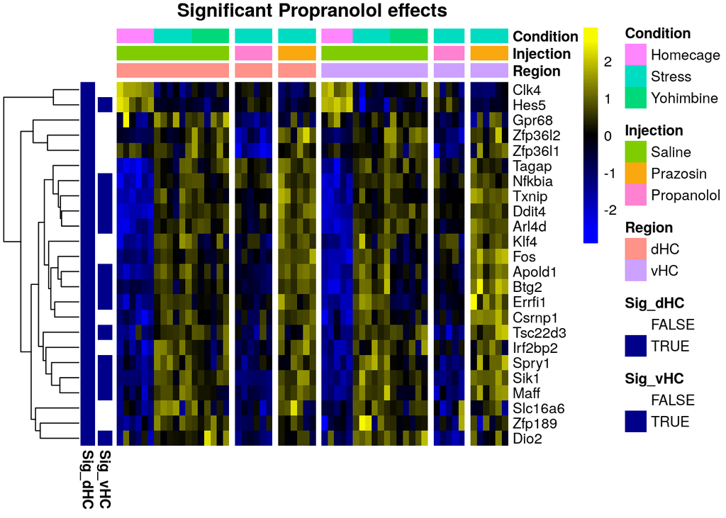

```r
#Here we produce a combined heatmap of genes with significant interaction, either in vHC or dHC
sig_int <- unique(rownames(topTags(Results[["STR2d_StressvsPropr"]],p = 0.05, n = Inf)),rownames(topTags(Results[["STR2v_StressvsPropr"]],p = 0.05, n = Inf)))
rowData(STR2)$Sig_vHC <- FALSE
rowData(STR2)$Sig_vHC[match(rownames(topTags(Results[["STR2v_StressvsPropr"]],p = 0.05, n = Inf)),rownames(STR2))] <- TRUE
rowData(STR2)$Sig_dHC <- FALSE
rowData(STR2)$Sig_dHC[match(rownames(topTags(Results[["STR2d_StressvsPropr"]],p = 0.05, n = Inf)),rownames(STR2))] <- TRUE

Fig1D <- sehm(STR2,
     sig_int,
     gaps_at = c("Region","Injection"),
     anno_columns = c("Region","Injection","Condition"),
     anno_rows = c("Sig_vHC","Sig_dHC"),
     do.scale = T,
     cluster_rows = T,
     main = "Significant Propranolol effects", assay = "corrected")
```

### Propranolol response strength vHC vs dHC (Fig1E)

This figure shows the strength of the stress vs stress + propranolol in vHC vs dHC

```r
vHC <- Results[["STR2v_StressvsPropr"]]$table
dHC <- Results[["STR2d_StressvsPropr"]]$table

df <- data.frame(gene = sig_int ,vHC = vHC[sig_int,"logFC"], dHC = dHC[sig_int,"logFC"])
df <- df[order(df$vHC),]
df$index <- 1:nrow(df)

Fig1E <- ggplot() + geom_point(data = df,aes(index, vHC), color = "blue") + geom_point(data = df,aes(index, dHC), color = "red") + scale_y_continuous(limits = c(-3,3)) + theme_bw() + ylab("logFC")
```

### Ctrl-swim vs ctrl-swim+praz strength (FigS1B)

This Figure shows the stength of the stress effect vs the stress + prazosin effect (combined hemispheres)

```r
vHC_sw <- Results[["STR2v_CtrlvsSwim"]]$table
dHC_sw <- Results[["STR2d_CtrlvsSwim"]]$table
vHC_swpra <- Results[["STR2v_CtrlvsPraz"]]$table
dHC_swpra <- Results[["STR2d_CtrlvsPraz"]]$table

#select genes that are expressed in all comparisons
temp <- intersect(intersect(rownames(vHC_sw),rownames(dHC_sw)),intersect(rownames(vHC_swpra),rownames(dHC_swpra)))

sw <- vHC_sw[temp,]
sw$logFC <- (sw$logFC + dHC_sw[temp,"logFC"]) / 2

sw_pra <- vHC_swpra[temp,]
sw_pra$logFC <- (sw_pra$logFC + dHC_swpra[temp,"logFC"]) / 2

df_swvswpra <- data.frame(sw = sw$logFC,sw_pra = sw_pra$logFC)
rownames(df_swvswpra) <- rownames(sw_pra)
df_swvswpra <- na.omit(df_swvswpra[sig_str,])
df_swvswpra <- df_swvswpra[order(df_swvswpra$sw),]
df_swvswpra$index <- 1:nrow(df_swvswpra)

FigS1B <- ggplot() + geom_point(data = df_swvswpra,aes(index, sw), color = "blue") + geom_point(data = df_swvswpra,aes(index, sw_pra), color = "red") + theme_bw() + ylab("logFC") + scale_y_continuous(limits = c(-3,3))
```

### Ctrl-swim vs ctrl-swim+prop strength (FigS1C)

This Figure shows the stength of the stress effect vs the stress + propranolol effect (combined hemispheres)

```r
vHC_sw <- Results[["STR2v_CtrlvsSwim"]]$table
dHC_sw <- Results[["STR2d_CtrlvsSwim"]]$table
vHC_swpro <- Results[["STR2v_CtrlvsPropr"]]$table
dHC_swpro <- Results[["STR2d_CtrlvsPropr"]]$table

#select genes that are expressed in all comparisons
temp <- intersect(intersect(rownames(vHC_sw),rownames(dHC_sw)),intersect(rownames(vHC_swpro),rownames(dHC_swpro)))

sw <- vHC_sw[temp,]
sw$logFC <- (sw$logFC + dHC_sw[temp,"logFC"]) / 2

sw_pro <- vHC_swpro[temp,]
sw_pro$logFC <- (sw_pro$logFC + dHC_swpro[temp,"logFC"]) / 2

df_swvswpro <- data.frame(sw = sw$logFC,sw_pro = sw_pro$logFC)
rownames(df_swvswpro) <- rownames(sw_pro)
df_swvswpro <- na.omit(df_swvswpro[sig_str,])
df_swvswpro <- df_swvswpro[order(df_swvswpro$sw),]
df_swvswpro$index <- 1:nrow(df_swvswpro)

FigS1C <- ggplot() + geom_point(data = df_swvswpro,aes(index, sw), color = "blue") + geom_point(data = df_swvswpro,aes(index, sw_pro), color = "red") + theme_bw() + ylab("logFC") + scale_y_continuous(limits = c(-3,3))
```

### Ctrl-swim vs ctrl- yohimbine strength (FigS1D)

This Figure shows the stength of the stress effect vs the yohimbine effect (combined hemispheres)

```r
vHC_sw <- Results[["STR2v_CtrlvsSwim"]]$table
dHC_sw <- Results[["STR2d_CtrlvsSwim"]]$table
vHC_yoh <- Results[["STR2v_CtrlvsYohimb"]]$table
dHC_yoh <- Results[["STR2d_CtrlvsYohimb"]]$table

#select genes that are expressed in all comparisons
temp <- intersect(intersect(rownames(vHC_sw),rownames(dHC_sw)),intersect(rownames(vHC_yoh),rownames(dHC_yoh)))

sw <- vHC_sw[temp,]
sw$logFC <- (sw$logFC + dHC_sw[temp,"logFC"]) / 2

yoh <- vHC_yoh[temp,]
yoh$logFC <- (yoh$logFC + dHC_yoh[temp,"logFC"]) / 2

df_swvsyoh <- data.frame(sw = sw$logFC,yoh = yoh$logFC)
rownames(df_swvsyoh) <- rownames(yoh)
df_swvsyoh <- na.omit(df_swvsyoh[sig_str,])
df_swvsyoh <- df_swvsyoh[order(df_swvsyoh$sw),]
df_swvsyoh$index <- 1:nrow(df_swvsyoh)

FigS1D <- ggplot() + geom_point(data = df_swvsyoh,aes(index, sw), color = "blue") + geom_point(data = df_swvsyoh,aes(index, yoh), color = "red") + theme_bw() + ylab("logFC") + scale_y_continuous(limits = c(-3,3))
```

### combined Ctrl-swim vs treatments strength (FigS1B-D)

```r
cmb <- intersect(intersect(rownames(df_swvsyoh),rownames(df_swvswpro)),rownames(df_swvswpra))
 FigS1BD <- ggplot() + geom_point(data = df_swvsyoh[cmb,],aes(index, sw), color = "blue") +
   geom_point(data = df_swvsyoh[cmb,],aes(index, yoh), color = "red") +
   geom_point(data = df_swvswpro[cmb,],aes(index, sw_pro), color = "green") +
   geom_point(data = df_swvswpra[cmb,],aes(index, sw_pra), color = "orange") +
   theme_bw() +
   ylab("logFC") +
   scale_y_continuous(limits = c(-3,3))
```

### Sotolol Experiment Heatmap (Fig1F)

This figure shows genes that are stress responsive, but also have a significant interaction with propranolol (p adj for stress effect, p-value for interaction)

```r
STR3 <- dosvacor(STR3, form = ~Condition * Injection)
```

```
## Number of significant surrogate variables is:  3
## Iteration (out of 5 ):1  2  3  4  5
```

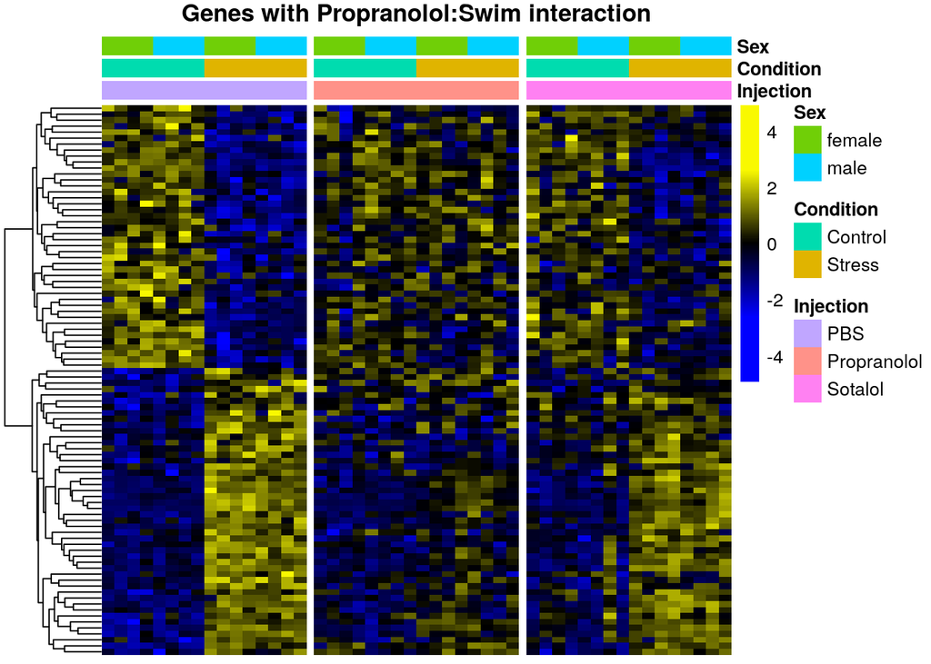

```r
STR3_design <- model.matrix(~STR3$Condition * STR3$Injection + STR3$SV1 + STR3$SV2 + STR3$SV3)

y <- DGEList(counts=assays(STR3)$counts)
y <- calcNormFactors(y)
y <- estimateDisp(y,STR3_design)
#filter out genes that are low expressed
y <- y[filterByExpr(y, STR3_design, min.count = mincount),]
STR3_fit <- glmQLFit(y,STR3_design)

Results[["STR3_FullModel"]] <- glmQLFTest(STR3_fit, colnames(STR3_design)[c(2:4,8,9)])
Results[["STR3_SwimEffect"]] <- glmQLFTest(STR3_fit, colnames(STR3_design)[2])
Results[["STR3_InteractionPropranolol"]] <- glmQLFTest(STR3_fit, colnames(STR3_design)[8])
Results[["STR3_InteractionSotolol"]] <- glmQLFTest(STR3_fit, colnames(STR3_design)[9])

sig_str3 <- rownames(topTags(Results[["STR3_FullModel"]],p = 0.05, n = Inf))
sig_str3_str <- rownames(topTags(Results[["STR3_SwimEffect"]],p = 0.05, n = Inf))

#Sig propranolol interaction
prop <- Results[["STR3_InteractionPropranolol"]]$table
prop <- prop[sig_str3_str,]
prop <- prop[prop$PValue < 0.05,]

Fig1F <- sehm(STR3,
     rownames(prop),
     gaps_at = "Injection",
     anno_columns = c("Injection","Condition","Sex"),
     do.scale = T,
     cluster_rows = T,
     main = "Genes with Propranolol:Swim interaction", assay = "corrected",)
```

### Sotolol Experiment female vs male (Fig1G)

```r
STR3_m <- STR3[,STR3$Sex == "male"]
STR3_f <- STR3[,STR3$Sex == "female"]

#males
STR3_design_m <- model.matrix(~STR3_m$Condition * STR3_m$Injection + STR3_m$SV1 + STR3_m$SV2 + STR3_m$SV3)

y <- DGEList(counts=assays(STR3_m)$counts)
y <- calcNormFactors(y)
y <- estimateDisp(y,STR3_design_m)
STR3_m_fit <- glmQLFit(y,STR3_design_m)

Results[["STR3_m_InteractionPropranolol"]] <- glmQLFTest(STR3_m_fit, colnames(STR3_design_m)[8])

#females
STR3_design_f <- model.matrix(~STR3_f$Condition * STR3_f$Injection + STR3_f$SV1 + STR3_f$SV2 + STR3_f$SV3)

y <- DGEList(counts=assays(STR3_f)$counts)
y <- calcNormFactors(y)
y <- estimateDisp(y,STR3_design_f)
STR3_f_fit <- glmQLFit(y,STR3_design_f)

Results[["STR3_f_InteractionPropranolol"]] <- glmQLFTest(STR3_f_fit, colnames(STR3_design_f)[8])

df2 <- data.frame(name = rownames(prop),
                            logFC.males = Results[["STR3_m_InteractionPropranolol"]]$table[rownames(prop),"logFC"],
                            logFC.females = Results[["STR3_f_InteractionPropranolol"]]$table[rownames(prop),"logFC"])

df2 <- df2[order(df2$logFC.males),]
df2$index <- 1:nrow(df2)

Fig1G <- ggplot() +
  geom_point(data = df2,aes(index, logFC.males), color = "blue") +
  geom_point(data = df2,aes(index, logFC.females), color = "red") +
  theme_bw() +
  ylab("logFC")
```

### Propranolol Genes of STR2 in STR2+STR3 (Figure S1E)

Heatmap that shows the significant propranolol genes of STR2 in combined data of STR2 and STR3

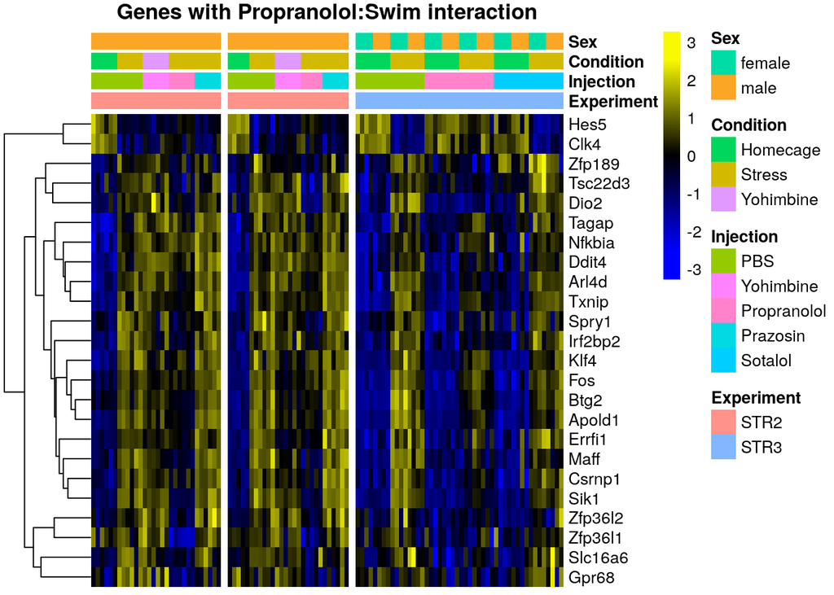

```r
STR$Injection[STR$Injection == "Propanolol"] <- "Propranolol"
STR$Injection[STR$Injection == "Saline"] <- "PBS"
STR$Injection <- factor(STR$Injection, levels = c("PBS","Yohimbine","Propranolol","Prazosin","Sotalol"))
STR$Injection[STR$Condition2 == "Saline-Yohimbine"] <- "Yohimbine"
STR$Sex[STR$Sex == "Male"] <- "male"
STR <- STR[,order(STR$Experiment, STR$Region, STR$Injection, STR$Condition, STR$Sex)]
FigS1E <- sehm(STR,
     sig_int,
     gaps_at = c("Experiment","Region"),
     anno_columns = c("Experiment","Injection","Condition","Sex"),
     do.scale = T,
     cluster_rows = T,
     main = "Genes with Propranolol:Swim interaction", assay = "corrected",)
```

### Expression of Dio2 (Figure S1F)

```r
plotdat <- meltSE(STR,c("Dio2"))

FigS1F <- ggplot(plotdat, aes(Injection, corrected, color = Condition)) +
  geom_boxplot(outlier.shape = NA) +
  geom_point(position = position_jitterdodge()) +
  facet_grid(feature~Region +Experiment, scales = "free") +
  theme_bw() +
  theme(axis.text.x = element_text(angle = 90, vjust = 0.5, hjust=1))
```

### Response strength STR3 (swim vs propranolol vs sotalol) (Figure S1G)

This figure shows the stress responsive genes with significant stress:propranolol interaction and their respective effect strength in PBS, Propranolol and Sotalol control vs swim comparisons

```r
STR3_contrasts <- dosvacor(STR3, form = ~Condition2)
```

```
##   Note: levels of factors in the design contain characters other than
##   letters, numbers, '_' and '.'. It is recommended (but not required) to use
##   only letters, numbers, and delimiters '_' or '.', as these are safe characters
##   for column names in R. [This is a message, not a warning or an error]
##   Note: levels of factors in the design contain characters other than
##   letters, numbers, '_' and '.'. It is recommended (but not required) to use
##   only letters, numbers, and delimiters '_' or '.', as these are safe characters
##   for column names in R. [This is a message, not a warning or an error]
```

```
## Number of significant surrogate variables is:  3
## Iteration (out of 5 ):1  2  3  4  5
```

```r
STR3_contrasts_design <- model.matrix(~STR3$Condition2 + STR3$SV1 + STR3$SV2 + STR3$SV3)

y <- DGEList(counts=assays(STR3_contrasts)$counts)
y <- calcNormFactors(y)
y <- estimateDisp(y,STR3_contrasts_design)
#filter out genes that are low expressed
y <- y[filterByExpr(y, STR3_contrasts_design, min.count = mincount),]
STR3_contrasts_fit <- glmQLFit(y,STR3_contrasts_design)

Results[["STR3_contrasts_PBS_CtrlvsSwim"]] <- glmQLFTest(STR3_contrasts_fit, contrast = c(0,1,0,0,0,0,0,0,0))
Results[["STR3_contrasts_Propranolol_CtrlvsSwim"]] <- glmQLFTest(STR3_contrasts_fit, contrast = c(0,0,-1,1,0,0,0,0,0))
Results[["STR3_contrasts_Sotalol_CtrlvsSwim"]] <- glmQLFTest(STR3_contrasts_fit, contrast = c(0,0,0,0,-1,1,0,0,0))

df_STR3_contrasts <- data.frame(PBS = Results[["STR3_contrasts_PBS_CtrlvsSwim"]]$table$logFC,
                                Prop = Results[["STR3_contrasts_Propranolol_CtrlvsSwim"]]$table$logFC,
                                Sot = Results[["STR3_contrasts_Sotalol_CtrlvsSwim"]]$table$logFC)
rownames(df_STR3_contrasts) <- rownames(Results[["STR3_contrasts_PBS_CtrlvsSwim"]]$table)

df_STR3_contrasts <- df_STR3_contrasts[rownames(prop),]
df_STR3_contrasts <- df_STR3_contrasts[order(df_STR3_contrasts$PBS),]
df_STR3_contrasts$index <- 1:nrow(df_STR3_contrasts)

Fig1G <- ggplot() +
  geom_point(data = df_STR3_contrasts,aes(index, PBS), color = "blue") +
  geom_point(data = df_STR3_contrasts,aes(index, Prop), color = "red") +
  geom_point(data = df_STR3_contrasts,aes(index, Sot), color = "green2") +
  theme_bw() +
  ylab("logFC")
```

## Show Final Figures

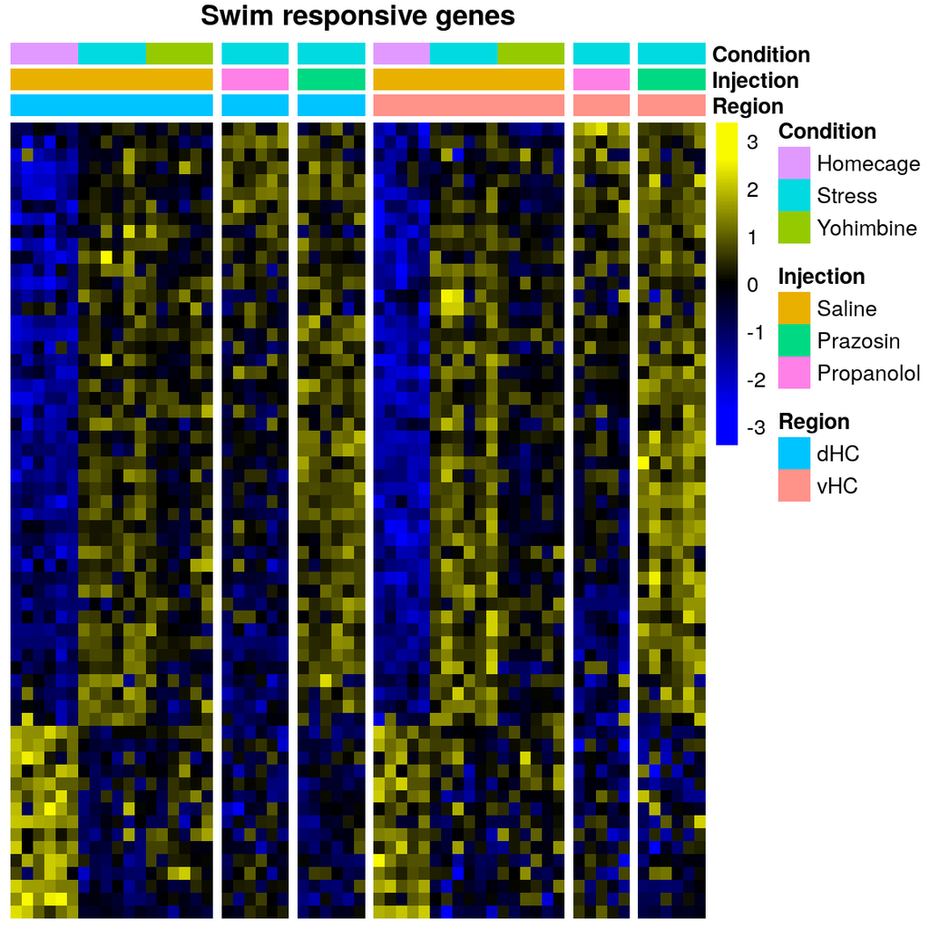

```r
print(Fig1B)
```

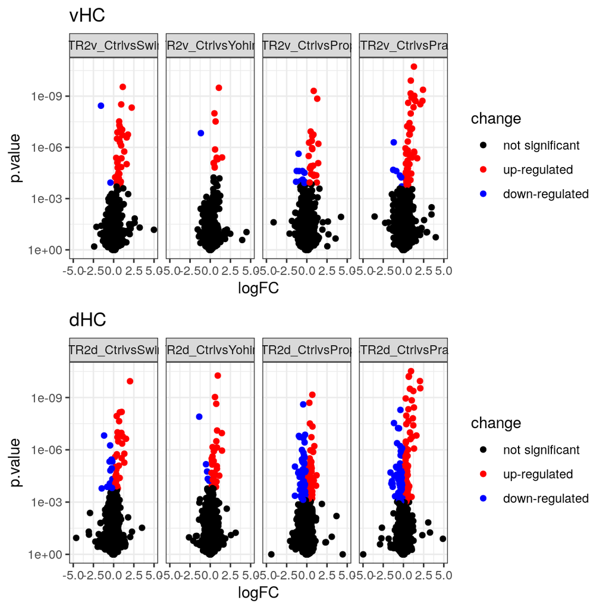

```r
print(Fig1C)
```

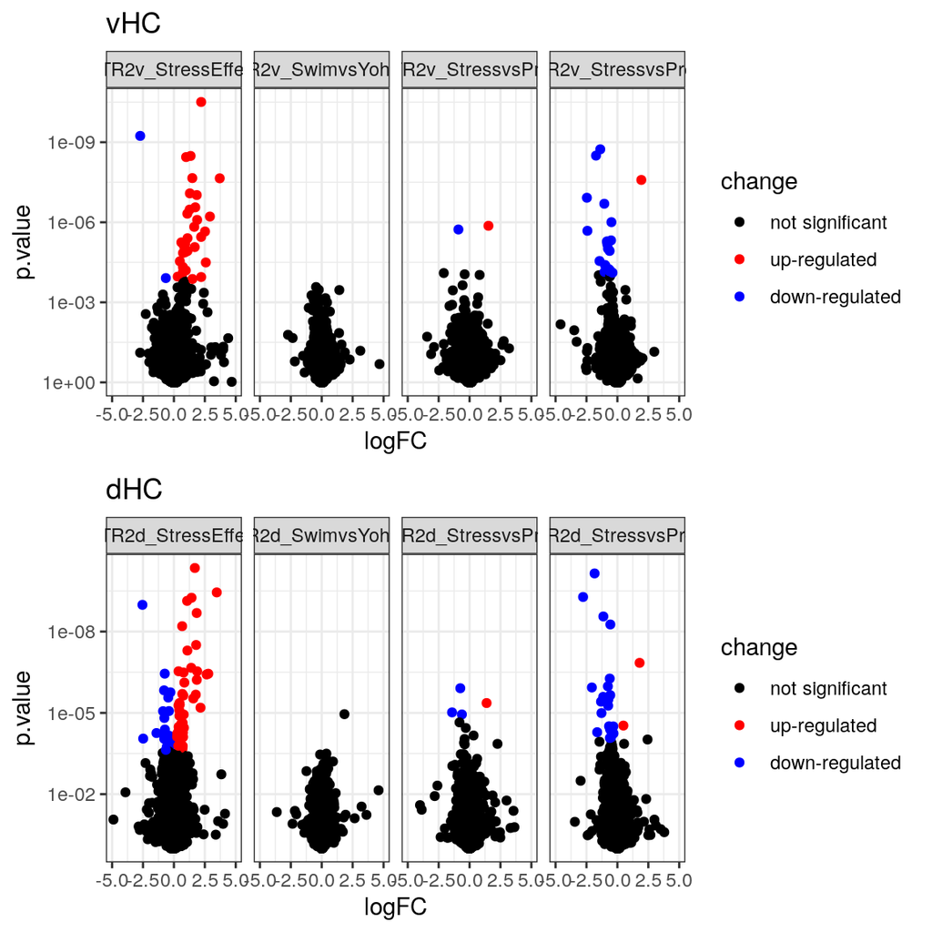

```r
print(FigS1A)
```

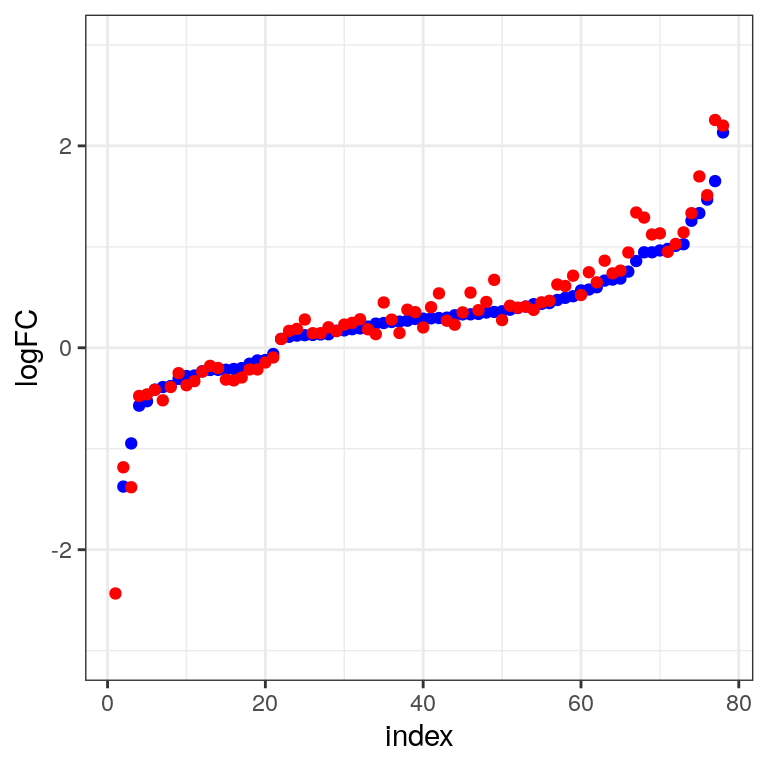

```r
print(FigS1B)
```

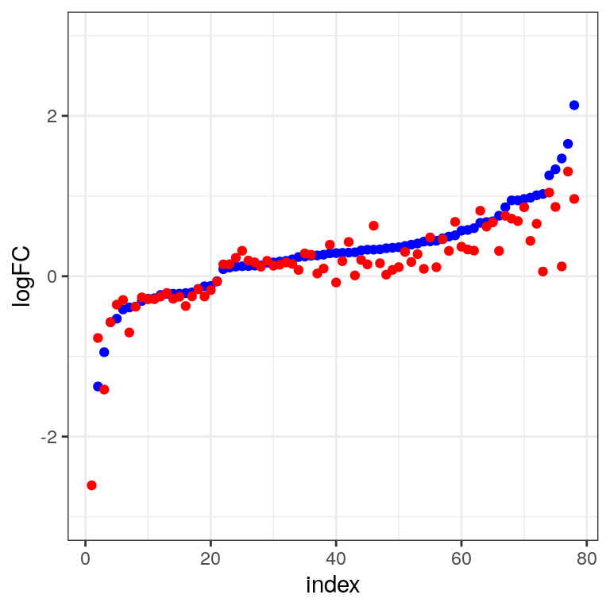

```r
print(FigS1C)
```

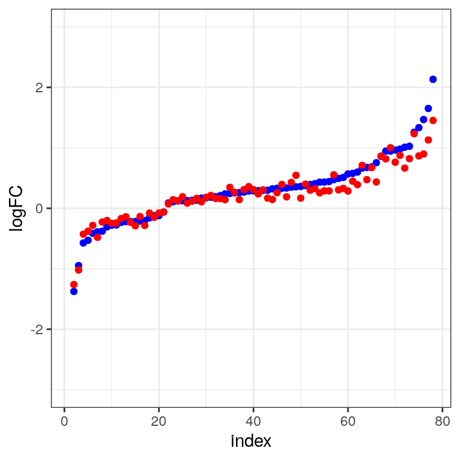

```r
print(FigS1D)
```

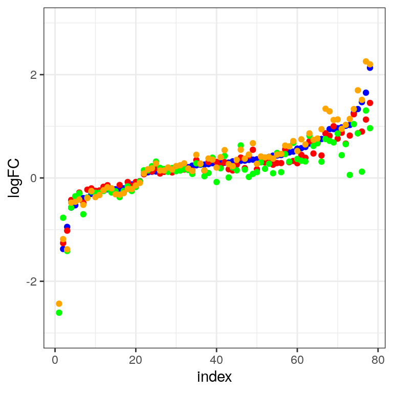

```r
print(FigS1BD)
```

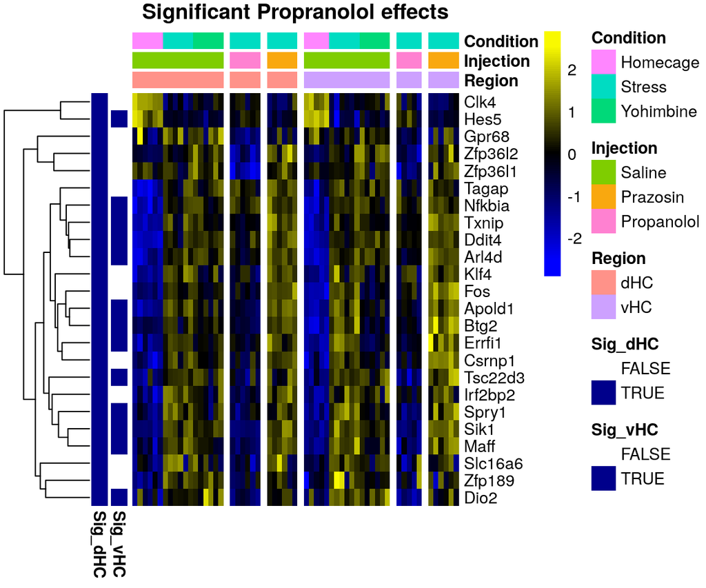

```r
print(Fig1D)
```

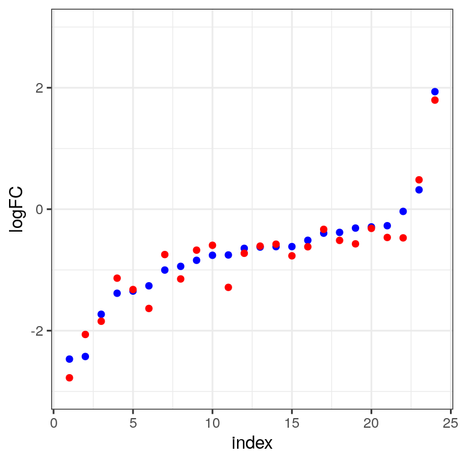

```r
print(Fig1E)
```

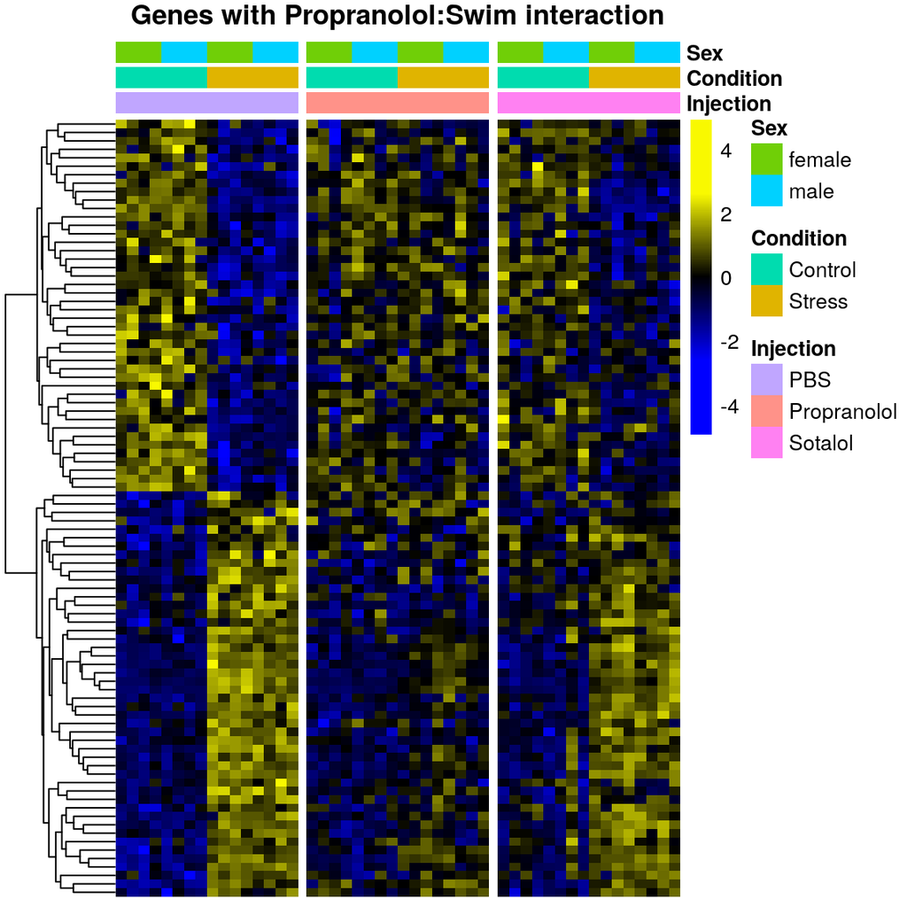

```r
print(Fig1F)
```

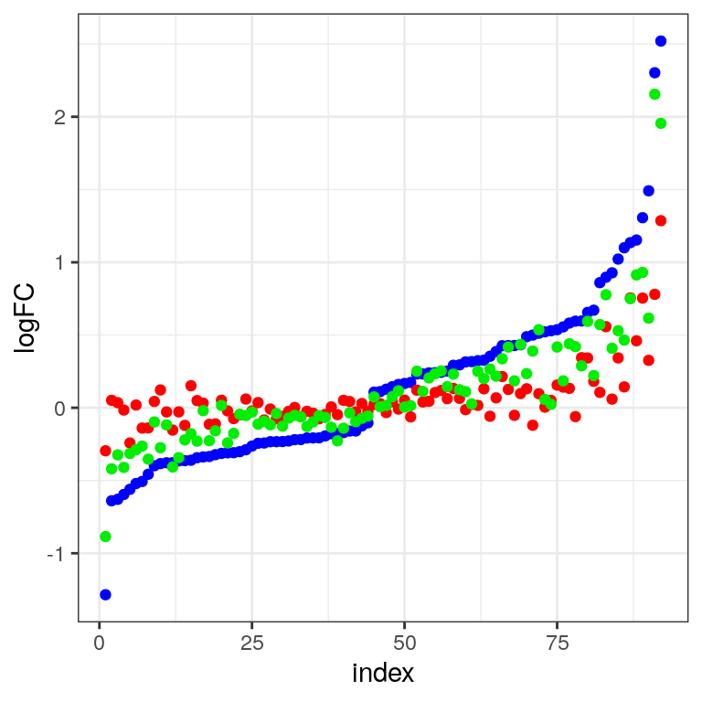

```r
print(Fig1G)
```

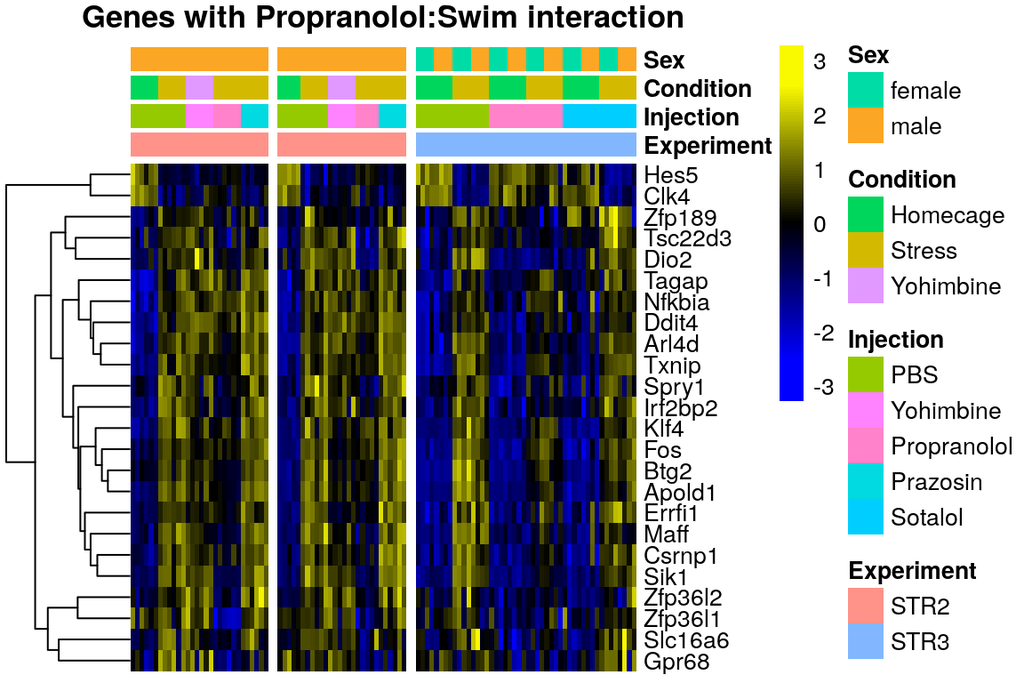

```r
print(FigS1E)
```

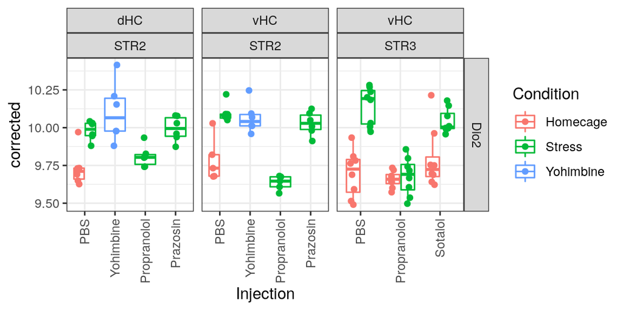

```r
print(FigS1F)
```

## Export Figures

```r
pdf(file = "../Figures/Fig1B.pdf", width = 6, height = 6)
print(Fig1B)
dev.off()
```

```r
pdf(file = "../Figures/Fig1C.pdf", width = 6, height = 6)
print(Fig1C)
dev.off()
```

```r
pdf(file = "../Figures/FigS1A.pdf", width = 6, height = 6)
print(FigS1A)
dev.off()
```

```r
pdf(file = "../Figures/FigS1B.pdf", width = 4, height = 4)
print(FigS1B)
dev.off()
```

```r
pdf(file = "../Figures/FigS1C.pdf", width = 4, height = 4)
print(FigS1C)
dev.off()
```

```r
pdf(file = "../Figures/FigS1D.pdf", width = 4, height = 4)
print(FigS1D)
dev.off()
```

```r
pdf(file = "../Figures/FigS1BD.pdf", width = 4, height = 4)
print(FigS1BD)
dev.off()
```

```r
pdf(file = "../Figures/Fig1D.pdf", width = 6, height = 5)
print(Fig1D)
dev.off()
```

```r
pdf(file = "../Figures/Fig1E.pdf", width = 4, height = 4)
print(Fig1E)
dev.off()
```

```r
pdf(file = "../Figures/Fig1F.pdf", width = 6, height = 6)
print(Fig1F)
dev.off()
```

```r
pdf(file = "../Figures/Fig1G.pdf", width = 4, height = 4)
print(Fig1G)
dev.off()
```

```r
pdf(file = "../Figures/FigS1E.pdf", width = 6, height = 4)
print(FigS1E)
dev.off()
```

```r
pdf(file = "../Figures/FigS1F.pdf", width = 6, height = 3)
print(FigS1F)
dev.off()
```

```r
pdf(file = "../Figures/Fig1G.pdf", width = 4, height = 4)
print(Fig1G)
dev.off()
```

## Create final data frames (containing corrected expression and Results data as single SE file, compatible with tinySEV)

```r
rowData(STR2)$Sig_vHC <- NULL
rowData(STR2)$Sig_dHC <- NULL

for(i in names(Results)){
  Results[[i]]$table$FDR <- p.adjust(Results[[i]]$table$PValue, method = "fdr")
}

rowData(STR2)$DEA.vHC_FullModel <- Results$STR2v_FullModel$table[rownames(STR2),]
attr(rowData(STR2)$DEA.vHC_FullModel, "description") <- "Full model analysis of vHC samples that tests if a gene is in general differentially expressed accross all 5 groups"

rowData(STR2)$DEA.dHC_FullModel<- Results$STR2d_FullModel$table[rownames(STR2),]
attr(rowData(STR2)$DEA.dHC_FullModel, "description") <- "Full model analysis of dHC samples that tests if a gene is in general differentially expressed accross all 5 groups"

rowData(STR2)$DEA.dHC_StressEffect<- Results$STR2d_StressEffect$table[rownames(STR2),]
attr(rowData(STR2)$DEA.dHC_StressEffect, "description") <- "Analysis that tests if a gene is differentially expressed after stress (either swim or yohimbine injection) vs ctrl in the dHC"

rowData(STR2)$DEA.vHC_StressEffect <- Results$STR2v_StressEffect$table[rownames(STR2),]
attr(rowData(STR2)$DEA.vHC_StressEffect, "description") <- "Analysis that tests if a gene is differentially expressed after stress (either swim or yohimbine injection) vs ctrl in the vHC"

rowData(STR2)$DEA.vHC_CtrlvsSwim <- Results$STR2v_CtrlvsSwim$table[rownames(STR2),]
attr(rowData(STR2)$DEA.vHC_CtrlvsSwim, "description") <- "Contrast analysis that tests if a gene is differentially expressed in swim vs control animals in the vHC"

rowData(STR2)$DEA.dHC_CtrlvsSwim <- Results$STR2d_CtrlvsSwim$table[rownames(STR2),]
attr(rowData(STR2)$DEA.dHC_CtrlvsSwim, "description") <- "Contrast analysis that tests if a gene is differentially expressed in swim vs control animals in the dHC"

rowData(STR2)$DEA.vHC_SwimvsYohimb <- Results$STR2v_SwimvsYohimb$table[rownames(STR2),]
attr(rowData(STR2)$DEA.vHC_SwimvsYohimb, "description") <- "Contrast analysis that tests if a gene is differentially expressed in swim vs yohimbine animals in the vHC"

rowData(STR2)$DEA.vHC_StressvsPraz <- Results$STR2v_StressvsPraz$table[rownames(STR2),]
attr(rowData(STR2)$DEA.vHC_StressvsPraz, "description") <- "Contrast analysis that tests if a gene is differentially expressed in stress (swim and yohimbin) vs swim + prazosin animals in the vHC"

rowData(STR2)$DEA.vHC_StressvsPropr <- Results$STR2v_StressvsPropr$table[rownames(STR2),]
attr(rowData(STR2)$DEA.vHC_StressvsPropr, "description") <- "Contrast analysis that tests if a gene is differentially expressed in stress (swim and yohimbin) vs swim + propranolol animals in the vHC"

rowData(STR2)$DEA.vHC_CtrlvsPropr <- Results$STR2v_CtrlvsPropr$table[rownames(STR2),]
attr(rowData(STR2)$DEA.vHC_CtrlvsPropr, "description") <- "Contrast analysis that tests if a gene is differentially expressed in ctrl vs swim + propranolol animals in the vHC"

rowData(STR2)$DEA.vHC_CtrlvsYohimb <- Results$STR2v_CtrlvsYohimb$table[rownames(STR2),]
attr(rowData(STR2)$DEA.vHC_CtrlvsYohimb, "description") <- "Contrast analysis that tests if a gene is differentially expressed in ctrl vs yohimbine animals in the vHC"

rowData(STR2)$DEA.vHC_CtrlvsPraz <- Results$STR2v_CtrlvsPraz$table[rownames(STR2),]
attr(rowData(STR2)$DEA.vHC_CtrlvsPraz, "description") <- "Contrast analysis that tests if a gene is differentially expressed in ctrl vs swim + prazosin animals in the vHC"

rowData(STR2)$DEA.dHC_SwimvsYohimb <- Results$STR2d_SwimvsYohimb$table[rownames(STR2),]
attr(rowData(STR2)$DEA.dHC_SwimvsYohimb, "description") <- "Contrast analysis that tests if a gene is differentially expressed in swim vs yohimbine animals in the dHC"


rowData(STR2)$DEA.dHC_StressvsPraz <- Results$STR2d_StressvsPraz$table[rownames(STR2),]
attr(rowData(STR2)$DEA.dHC_StressvsPraz, "description") <- "Contrast analysis that tests if a gene is differentially expressed in stress (swim and yohimbin) vs swim + prazosin animals in the dHC"

rowData(STR2)$DEA.dHC_StressvsPropr <- Results$STR2d_StressvsPropr$table[rownames(STR2),]
attr(rowData(STR2)$DEA.dHC_StressvsPropr, "description") <- "Contrast analysis that tests if a gene is differentially expressed in stress (swim and yohimbin) vs swim + propranolol animals in the dHC"

rowData(STR2)$DEA.dHC_CtrlvsPropr <- Results$STR2d_CtrlvsPropr$table[rownames(STR2),]
attr(rowData(STR2)$DEA.dHC_CtrlvsPropr, "description") <- "Contrast analysis that tests if a gene is differentially expressed in ctrl vs swim + propranolol animals in the dHC"

rowData(STR2)$DEA.dHC_CtrlvsYohimb <- Results$STR2d_CtrlvsYohimb$table[rownames(STR2),]
attr(rowData(STR2)$DEA.dHC_CtrlvsYohimb, "description") <- "Contrast analysis that tests if a gene is differentially expressed in ctrl vs yohimbine animals in the dHC"

rowData(STR2)$DEA.dHC_CtrlvsPraz <- Results$STR2d_CtrlvsPraz$table[rownames(STR2),]
attr(rowData(STR2)$DEA.dHC_CtrlvsPraz, "description") <- "Contrast analysis that tests if a gene is differentially expressed in ctrl vs swim + prazosin animals in the dHC"

metadata(STR2)$default_view <- list(assay = "corrected", groupvar = "Injection", colvar = "Condition", gridvar = "Region")
metadata(STR2)$description <- "In this experiment the effect of pharmacological noradrenaline (NA) interventions on the transcriptomic acute stress response is assessed. 5 groups are present in this dataset. saline - control, saline - swim, yohimbin, propranolol - swim, prazosin - swim. The standard swim response is captured by the saline - swim group. The yohimbin group is an acute injection of yohimbin, an alpha-2 adrenergic antagonist that increases NA release of the LC in the hippocampus. the propranolol - swim group combines propranolol (a beta adrenergic receptor blocker) with acute swim stress. the prazosin - swim group comibnes prazosin (an alpha adrenergic receptor blocker) with acute swim stress. swim stress and yohimbine are administered 45min prior to sacrifice. for each animal vHC and dHC samples were collected and analyzed independently within these two regions"


saveRDS(STR2,"../final_data/STR2_Complete.SE.Rds")


rowData(STR3)$DEA.FullModel <- Results$STR3_FullModel$table[rownames(STR3),]
attr(rowData(STR3)$DEA.FullModel, "description") <- "Analysis of the full model analysis swim * injection. Tests if a gene is in general variable across these variables"

rowData(STR3)$DEA.SwimEffect <- Results$STR3_SwimEffect$table[rownames(STR3),]
attr(rowData(STR3)$DEA.SwimEffect, "description") <- "Analysis of the swim coefficient of the swim * injection analysis. Tests if a gene is swim stress responsive"

rowData(STR3)$DEA.InteractionPropranolol <- Results$STR3_InteractionPropranolol$table[rownames(STR3),]
attr(rowData(STR3)$DEA.InteractionPropranolol, "description") <- "Analysis of the swim:propranolol interaction of the swim * injection analysis. Tests if a gene reacts differently to swim when propranolol is administred"

rowData(STR3)$DEA.InteractionSotolol <- Results$STR3_InteractionSotolol$table[rownames(STR3),]
attr(rowData(STR3)$DEA.InteractionSotolol, "description") <- "Analysis of the swim:sotalol interaction of the swim * injection analysis. Tests if a gene reacts differently to swim when sotalol is administred"

rowData(STR3)$DEA.male_InteractionPropranolol <- Results$STR3_m_InteractionPropranolol$table[rownames(STR3),]
attr(rowData(STR3)$DEA.male_InteractionPropranolol, "description") <- "Analysis of the swim:propranolol interaction of the swim * injection analysis in males only. Tests if a gene reacts differently to swim when propranolol is administred"

rowData(STR3)$DEA.female_InteractionPropranolol <- Results$STR3_f_InteractionPropranolol$table[rownames(STR3),]
attr(rowData(STR3)$DEA.female_InteractionPropranolol, "description") <- "Analysis of the swim:propranolol interaction of the swim * injection analysis in females only. Tests if a gene reacts differently to swim when propranolol is administred"

rowData(STR3)$DEA.PBS_CtrlvsSwim <- Results$STR3_contrasts_PBS_CtrlvsSwim$table[rownames(STR3),]
attr(rowData(STR3)$DEA.PBS_CtrlvsSwim, "description") <- "Contrast analysis of swim vs control in PBS injected animals"

rowData(STR3)$DEA.Propranolol_CtrlvsSwim <- Results$STR3_contrasts_Propranolol_CtrlvsSwim$table[rownames(STR3),]
attr(rowData(STR3)$DEA.Propranolol_CtrlvsSwim, "description") <- "Contrast analysis of swim vs control in Propranolol injected animals"

rowData(STR3)$DEA.Sotalol_CtrlvsSwim <- Results$STR3_contrasts_Sotalol_CtrlvsSwim$table[rownames(STR3),]
attr(rowData(STR3)$DEA.Sotalol_CtrlvsSwim, "description") <- "Contrast analysis of swim vs control in Sotalol injected animals"

metadata(STR3)$default_view <- list(assay = "corrected", groupvar = "Injection", colvar = "Condition")
metadata(STR3)$description <- "In this experiment the effect of pharmacological noradrenaline (NA) interventions on the transcriptomic acute stress response is assessed. Two independent variables are included, Condition (swim or control) and Injection (PBS, propranolo, sotalol). propranolol is a beta adrenergic blocker that acts in the periphery and in the CNS whereas sotalol is a beta adrenergic blocker that only acts in the periphery. Analysis was done with an interactive model Condition * Injection, that tests for swim effect and swim:injection interactions"


saveRDS(STR3,"../final_data/STR3_Complete.SE.Rds")
```